# Variable Selection in topic models: (K=2)

Kushal K Dey

December 26, 2015

## Overview

Variable selection in topic models or in cellcyleR methods is an important matter of consideration. In this script, we shall consider an example simulation model for topic models and then we apply variable selecion using sparse factor analysis. We use the *PMD()* function of the R package **PMA** for factor analysis and then use the factor loadings matrix to do the variable selection.

## Simulation design

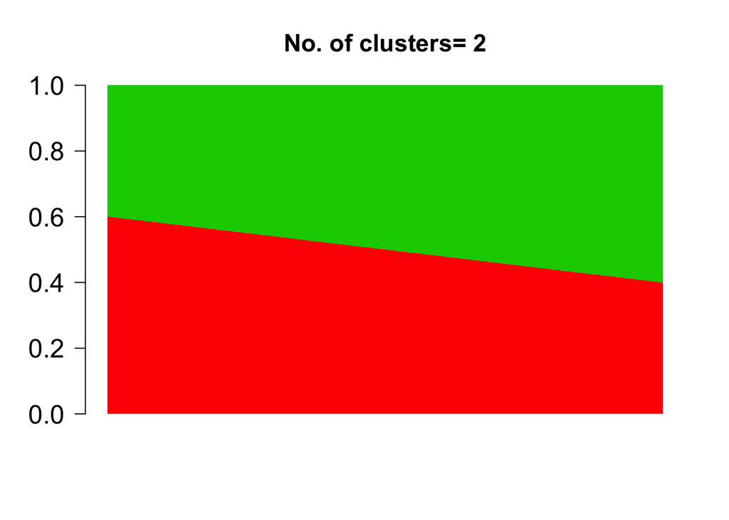

```r
library(maptpx)
n.out <- 200
omega_sim <- cbind(seq(0.6,0.4,length.out=n.out), 1- seq(0.6,0.4,length.out=n.out));
K <- dim(omega_sim)[2];
barplot(t(omega_sim),col=2:(K+1),axisnames=F,space=0,border=NA,main=paste("No. of clusters=",K),las=1,ylim=c(0,1),cex.axis=1.5,cex.main=1.4)
```

```r
freq <- rbind(c(0.1,0.2,rep(0.70/98,98)),c(rep(0.70/98,98), 0.1,0.2));
counts <- t(do.call(cbind,lapply(1:dim(omega_sim)[1], function(x) rmultinom(1,1000,prob=omega_sim[x,]%*%freq))));
```

By the way we have defined the set up, besides the first two and the last two genes, all the other genes are unimportant, or in other words, all the essential information required for the clustering is contained in the first two and the last two genes only. Ideally, we would like to eliminate the non-informative genes before applying the topic model for more accurate representation, removing unwanted noise and also faster implementation.

## Topic model without variable selection

We first apply the topic model without variable selection pre-processing.

```r
system.time(Topic_clus <- topics(counts, K=2,tol=0.001));
```

```
##
## Estimating on a 200 document collection.
## Fitting the 2 topic model.
## log posterior increase: 18.411, 46.33, 0.73, 0.73, 0.754, 0.805, 0.889, 1.016, 1.194, 1.431, 1.725, 2.046, 2.323, 2.466, 2.424, 2.227, 1.953, 1.67, 1.414, 1.194, 1.009, 0.853, 0.722, 0.609, 0.512, 0.428, 0.356, 0.294, 0.242, 0.198, 0.161, 0.187, 0.003, 0.001, done.
```

```
##    user  system elapsed
##   2.085   0.085   2.177
```

```r
K=2
docweights <- Topic_clus$omega;
library(permute);
library("BioPhysConnectoR");
```

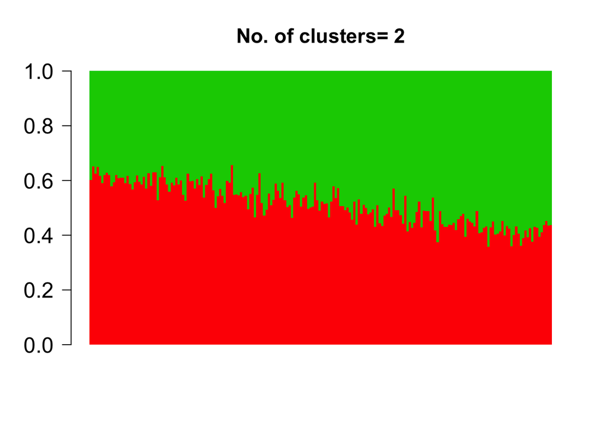

```r
perm_set=rbind(1:K,allPerms(1:K));
diff=array(0,dim(perm_set)[1]);
for (p in 1:dim(perm_set)[1])
{
    temp=docweights[,perm_set[p,]];
    diff[p]=fnorm(temp,omega_sim);
}

p_star=which(diff==min(diff));
docweights=docweights[,perm_set[p_star,]];

barplot(t(docweights),col=2:(K+1),axisnames=F,space=0,border=NA,main=paste("No. of clusters=",K),las=1,ylim=c(0,1),cex.axis=1.5,cex.main=1.4)
```

## Factor analysis on data

Now we perform the variable selection. Before applying the factor analysis model, we first mean correct the columns and rows.

```r
data_norm1 <- apply(counts,2,function(x) return(x-mean(x)));
data_norm2 <- apply(data_norm1, 1, function(x) return(x-mean(x)));
```

Then we perform factor analysis on the genes.

```r
library(PMA)
pmd1 <- PMD(data_norm2, type="standard", K=2, niter=50);
```

```
## 12345678910111213141516
## 12345678910111213141516171819202122232425
```

We plot the barplot of the factor loadings, colors representing the two factors.

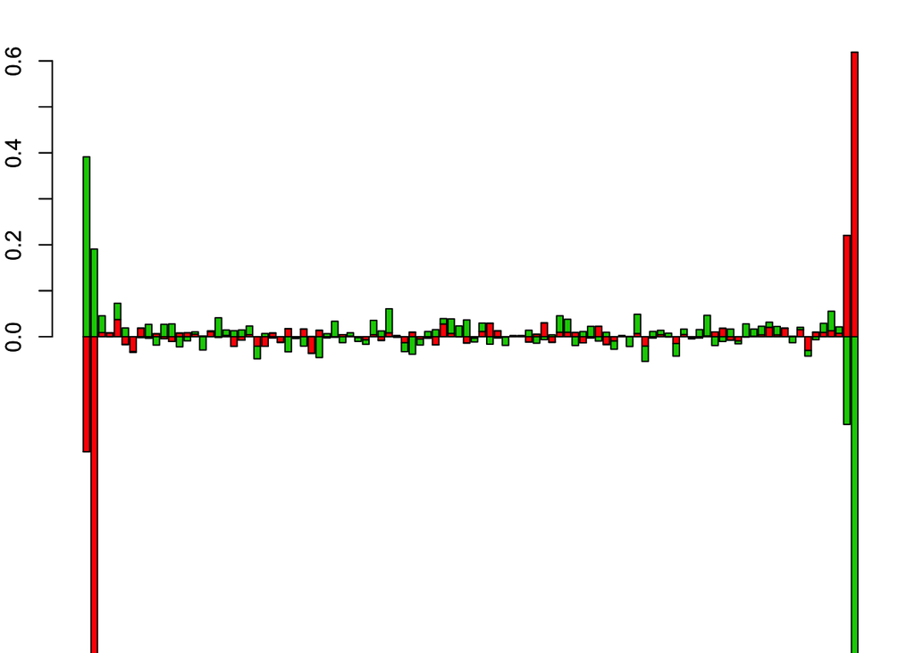

```r
pos_u <- apply(pmd1$u, c(1,2), function(x) return (max(x,0)))
neg_u <- apply(pmd1$u, c(1,2), function(x) return (min(x,0)))

par(mar=c(12,2,2,1))
barplot(t(pos_u), col=2:3)
barplot(t(neg_u), col=2:3, add=TRUE)
```

## Shrinking factor loadings

From the barplot, it is clear that the first two and the last two genes have very high loadings and are informative about clustering. So, these genes need to be kept in the clustering. However, the other genes which are non-informative still have small loadings. We use shrinkage to shrink these small values to 0.

The sum of squared values of the columns of $u$ matrix from *PMD()* fit is 1 by definition. Check here

```r
apply(pmd1$u,2,function(x) return(sqrt(sum(x^2))))
```

```
## [1] 1 1
```

We assume that all the genes contribute equally to this variance or standard deviation of $1$ in the $u$ matrix and we assume the variance to be $1/G$, whhere $G$ is the total number of genes.

```r
library(ashr)
shrunk_u <- suppressWarnings(apply(pmd1$u, 2, function(x) return(ash(x,sqrt(1/length(x)))$PosteriorMean)));
```

```
## Due to absence of package REBayes, switching to EM algorithm
## Due to absence of package REBayes, switching to EM algorithm
```

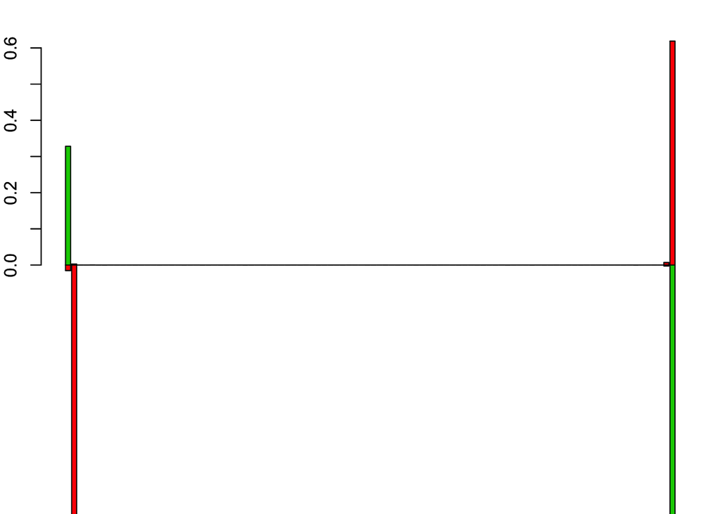

```r
pos_shrunk_u <- apply(shrunk_u, c(1,2), function(x) return (max(x,0)))
neg_shrunk_u <- apply(shrunk_u, c(1,2), function(x) return (min(x,0)))

par(mar=c(12,2,2,1))
barplot(t(pos_shrunk_u), col=2:3)
barplot(t(neg_shrunk_u), col=2:3, add=TRUE)
```

We compute the sum of squares of the loadings for the shrunken $u$ matrix. We choose the threshold to be $0.001$ for the loadings for choosing the genes.

## Topic model after variable selection (thresh=0.001)

```r
ss_loadings <- apply(shrunk_u,1,function(x) return(sqrt(sum(x^2))))
which(ss_loadings > 1e-03)
```

```
## [1]   1   2  99 100
```

We now perform topic model on the selected genes.

```r
vs_counts <- counts[,which(ss_loadings > 1e-03)];
system.time(Topic_clus <- topics(vs_counts, K=2,tol=0.001));
```

```
##
## Estimating on a 200 document collection.
## Fitting the 2 topic model.
## log posterior increase: 50.963, 0.464, 0.496, 0.007, 0.25, 0.002, 0.001, 0.002, 0.001, 0.001, done.
```

```
##    user  system elapsed
##   0.096   0.002   0.098
```

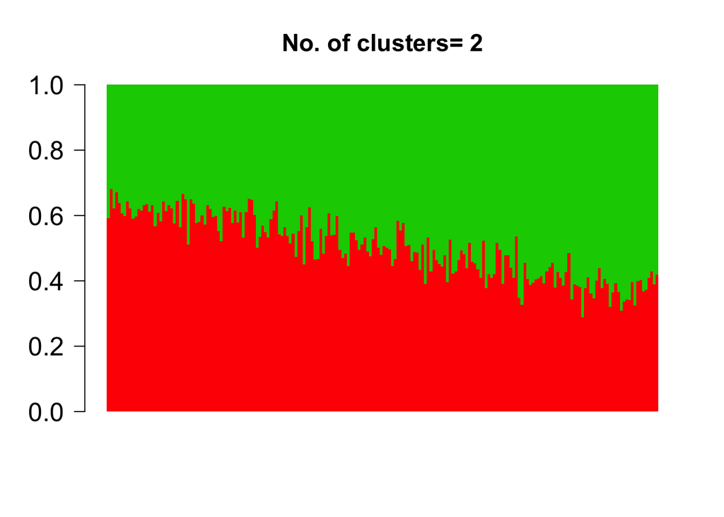

```r
K=2
barplot(t(Topic_clus$omega),col=2:(K+1),axisnames=F,space=0,border=NA,main=paste("No. of clusters=",K),las=1,ylim=c(0,1),cex.axis=1.5,cex.main=1.4)
```

## Topic model after variable selection (thresh=0.0001)

```r
ss_loadings <- apply(shrunk_u,1,function(x) return(sqrt(sum(x^2))))
which(ss_loadings > 1e-04)
```

```
##  [1]   1   2   5  18  30  31  40  43  50  72  73  81  97  99 100
```

We now perform topic model on the selected genes.

```r
vs_counts <- counts[,which(ss_loadings > 1e-04)];
system.time(Topic_clus <- topics(vs_counts, K=2,tol=0.001));
```

```
##
## Estimating on a 200 document collection.
## Fitting the 2 topic model.
## log posterior increase: 17.755, 1.318, 1.221, 1.322, 1.731, 2.751, 4.921, 7.801, 8.01, 1.655, 1.071, 0.593, 0.004, 0.009, done.
```

```
##    user  system elapsed
##   0.207   0.002   0.210
```

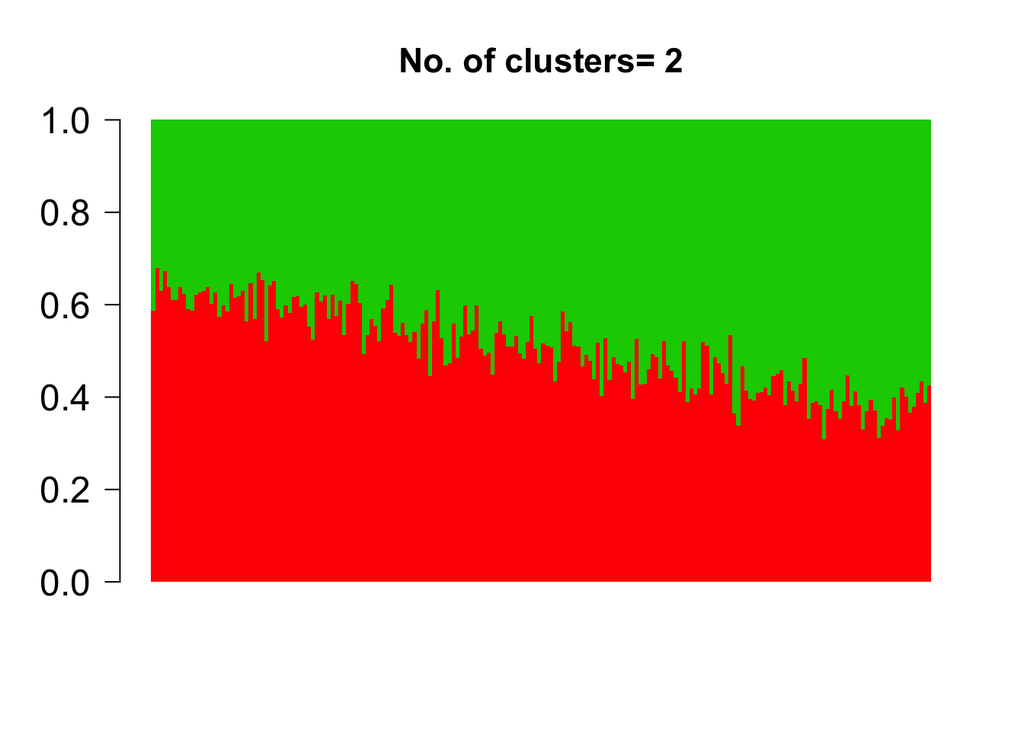

```r
K=2
docweights <- Topic_clus$omega;
library(permute);
library("BioPhysConnectoR");
perm_set=rbind(1:K,allPerms(1:K));
diff=array(0,dim(perm_set)[1]);
for (p in 1:dim(perm_set)[1])
{
    temp=docweights[,perm_set[p,]];
    diff[p]=fnorm(temp,omega_sim);
}

p_star=which(diff==min(diff));
docweights=docweights[,perm_set[p_star,]];

barplot(t(docweights),col=2:(K+1),axisnames=F,space=0,border=NA,main=paste("No. of clusters=",K),las=1,ylim=c(0,1),cex.axis=1.5,cex.main=1.4)
```

## Conclusion

Note that the topic model after variable selection gives pretty much similar structure plot representation and also at a much quicker time. This shows the efficacy of this approach over the usual approach. In the topic model set up, we assume that the samples are independent and not time ordered. For cellcycleR where the observations are time ordered, one may want to apply the factor analysis on the wavelet transforms of the data instead on actual data.